# MFW

Dana Roemling

2025-04-08

## Most Frequent Words

The goal for this markdown is to find the most frequent words - or better to create a matrix that has all words and all texts so you can see which word occurs how often in which text.

### Preparation

```r
library(tidyverse)
library(tidytext)
library(tidyr)
library(stringr)
library(readr)
library(ggplot2)
library(scales)
```

I’ll use the *awesome* data we’ve had a look at in class for this example. I create a list of all file names and then get the names for each author so I can make sure the matrices I create are per author.

```r
# Change this according to your system & needs
path_to_known <- "/Users/dana/Documents/Teaching (recent)/HY/Week 5/JEF_DIC/"
path_to_disputed <- "/Users/dana/Documents/Teaching (recent)/HY/Week 5/DISPUTED"

# List all .txt files in the known folder
all_files <- list.files(path_to_known, pattern = "\\.txt$", full.names = TRUE)

# Filter files that contain "JEF_" or "DIC_"
jef_files <- all_files[grepl("^JEF", basename(all_files))]
dic_files <- all_files[grepl("^DIC", basename(all_files))]
```

### Preprocessing

I decided to strip punctuation and to lowercase (which are analytical choices you may not agree with!), but I kept apostrophes in words like “isn’t”.  
Note that I only read in the txt files after I create the preprocessing function so I can apply it.

```r
# Function to read and preprocess a file
read_and_clean <- function(file) {
  text <- read_file(file)
  # Remove punctuation except apostrophes, convert to lowercase
  text_clean <- tolower(text)
  text_clean <- str_replace_all(text_clean, "[^\\w\\s']+", "")  # keep apostrophes
  tibble(filename = basename(file), text = text_clean)
}

# Read all files per author
dic_texts <- map_dfr(dic_files, read_and_clean)
jef_texts <- map_dfr(jef_files, read_and_clean)
```

### Matrices

This next bit does all the work, it tokenises and then counts all the words. Note that only words that occur at least once will show up in the matrices. Note also that these are raw frequencies, nothing is normalised in this step.

```r
# Tokenise into words and count per file
tokenise_count <- function(df) {
  df %>%
    unnest_tokens(word, text, token = "words") %>%
    count(filename, word) %>%
    pivot_wider(names_from = word, values_from = n, values_fill = 0) %>%
    arrange(filename)
}

# Create document-term matrices
dic_matrix <- tokenise_count(dic_texts)
jef_matrix <- tokenise_count(jef_texts)
```

### Normalisation

You can normalise per text or per author depending on what you are analysing/comparing. Usually:  
Comparing documents/texts? → Normalise per file  
Comparing authors’ styles? → Normalise per author

For the sake of the matrix, we treat each file as a mini-corpus for which we normalise, so we can then see which words occur frequent across texts and are a sign of an author’s style.

Options to normalise per author (all words by that person) would be for example to look at the sum of each word of that author and normalise the overall count [code below if you need it]. But since I’m after a matrix in this case, let’s normalise per file (to account for the text length).  
In this case I also decided to scale per 1,000,000 words to make the numbers a bit easier to appreciate. Change the scale argument in the normalise_matrix function to use a different scale. This defaults to the pmw now.

```r
# Function to normalise each row (i.e., per file)
normalise_matrix <- function(df, scale = 1e6) {
  filenames <- df$filename
  word_counts <- df %>% select(-filename)

  # Total words per file
  row_totals <- rowSums(word_counts)

  # Divide each cell in a row by the total words in that row
  normalised <- sweep(word_counts, 1, row_totals, FUN = "/") * scale

  # Round the results to two decimal places
  normalised <- round(normalised, 2)

  # Add filename column back
  normalised_df <- bind_cols(tibble(filename = filenames), as_tibble(normalised))

  return(normalised_df)
}

# Apply to DIC and JEF matrices
dic_matrix_norm <- normalise_matrix(dic_matrix, scale = 1e6)
jef_matrix_norm <- normalise_matrix(jef_matrix, scale = 1e6)
```

This looks at the total number of occurrences per author and normalises those. You could add, like above, to do this pmw.

```r
# Remove filename column and convert to matrix
normalise_matrix <- function(df) {
  word_counts <- df %>% select(-filename)
  total_words <- sum(word_counts)
  word_totals <- colSums(word_counts)
  word_frequencies <- word_totals / total_words

  # Format to avoid scientific notation
  word_frequencies <- format(word_frequencies, scientific = FALSE)

  tibble(word = names(word_frequencies), freq = word_frequencies)
}

# Get normalised frequency per author
dic_freq <- normalise_matrix(dic_matrix)
jef_freq <- normalise_matrix(jef_matrix)

# View top frequent words
dic_freq %>%
  arrange(desc(freq)) %>%
  head(10)
```

```
## # A tibble: 10 × 2
##    word  freq
##    <chr> <chr>
##  1 the   0.063707694109
##  2 of    0.045519651914
##  3 to    0.035475240300
##  4 and   0.030403488068
##  5 in    0.017962831173
##  6 a     0.016971902673
##  7 that  0.016098083905
##  8 be    0.015296332664
##  9 is    0.011035340114
## 10 by    0.010882196618
```

```r
jef_freq %>%
  arrange(desc(freq)) %>%
  head(10)
```

```
## # A tibble: 10 × 2
##    word  freq
##    <chr> <chr>
##  1 the   0.070759316937
##  2 of    0.050245945656
##  3 to    0.037246267855
##  4 and   0.028491032113
##  5 in    0.018837933627
##  6 a     0.016470840941
##  7 that  0.013562453013
##  8 be    0.012866501987
##  9 it    0.011925679304
## 10 is    0.010297497584
```

### Plotting MFW

Now we can also plot things again, which might help to understand what we’ve just done or to explain it to others. This bit will just look at the most frequent words per author.

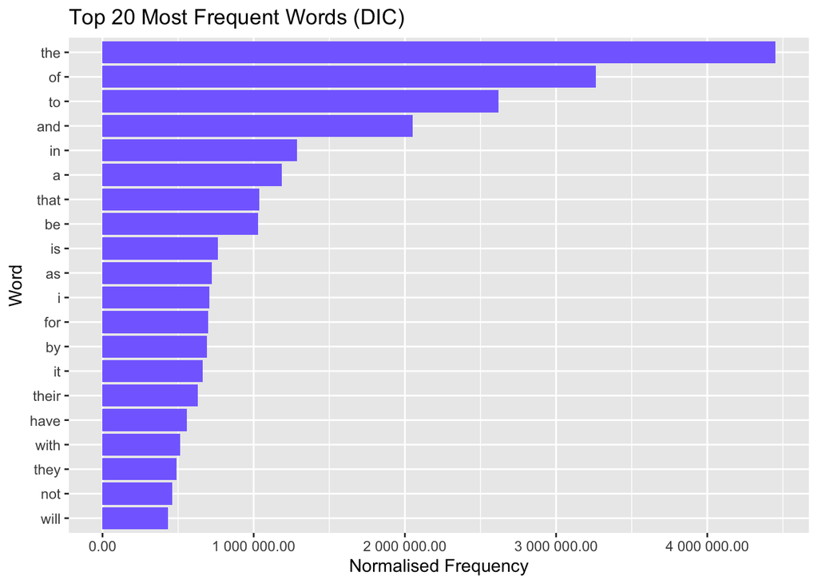

```r
# Get word frequencies for DIC and JEF
dic_word_frequencies <- dic_matrix_norm %>%
  select(-filename) %>%
  colSums()

jef_word_frequencies <- jef_matrix_norm %>%
  select(-filename) %>%
  colSums()

# Create data frames for plotting
dic_word_df <- tibble(word = names(dic_word_frequencies), freq = dic_word_frequencies)
jef_word_df <- tibble(word = names(jef_word_frequencies), freq = jef_word_frequencies)

# Top N (e.g., top 20) words
top_n <- 20
dic_top_n_words <- dic_word_df %>%
  arrange(desc(freq)) %>%
  head(top_n)

jef_top_n_words <- jef_word_df %>%
  arrange(desc(freq)) %>%
  head(top_n)

# Plot DIC top N words
ggplot(dic_top_n_words, aes(x = reorder(word, freq), y = freq)) +
  geom_bar(stat = "identity", fill = "lightslateblue") +
  coord_flip() +
  scale_y_continuous(labels = label_number(scale = 1, suffix = "", accuracy = 0.01)) +
  labs(title = "Top 20 Most Frequent Words (DIC)", x = "Word", y = "Normalised Frequency")
```

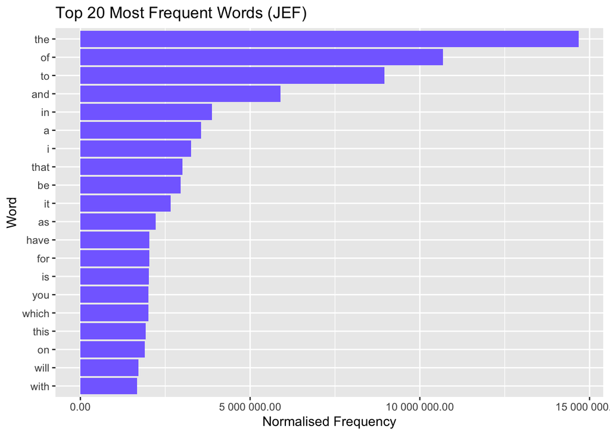

```r
# Plot JEF top N words
ggplot(jef_top_n_words, aes(x = reorder(word, freq), y = freq)) +
  geom_bar(stat = "identity", fill = "lightslateblue") +
  coord_flip() +
  scale_y_continuous(labels = label_number(scale = 1, suffix = "", accuracy = 0.01)) +
  labs(title = "Top 20 Most Frequent Words (JEF)", x = "Word", y = "Normalised Frequency")
```

### Plotting single words of interest

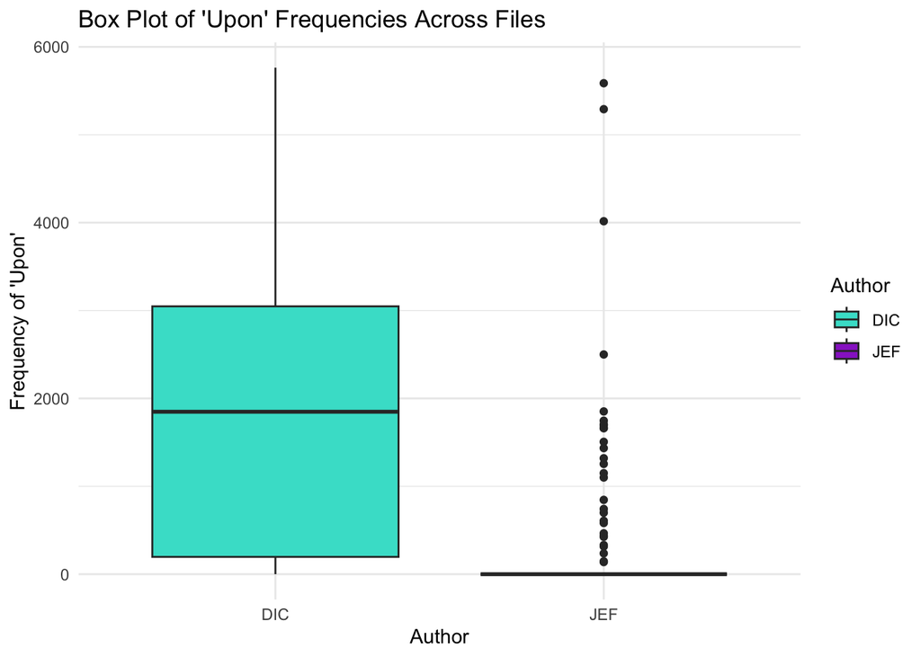

```r
# Filter the normalised data for the word of interest (exact match!)
dic_single_word <- dic_matrix_norm %>%
  select(filename, matches("^upon$"))

jef_single_word <- jef_matrix_norm %>%
  select(filename, matches("^upon$"))

# Add a column for the author (to distinguish between DIC and JEF)
dic_single_word$author <- "DIC"
jef_single_word$author <- "JEF"

# Combine the data
single_word_data <- bind_rows(dic_single_word, jef_single_word)

# Gather the data into a tidy format for plotting
single_word_data_long <- single_word_data %>%
  pivot_longer(cols = -c(filename, author), names_to = "word", values_to = "frequency")

# Define custom colours for each author
custom_colours <- c("DIC" = "turquoise",
                   "JEF" = "darkorchid")

# The actual plot
ggplot(single_word_data_long,
       aes(x = author,
           y = frequency,
           fill = author)) +
  geom_boxplot() +
  labs(title = "Box Plot of 'Upon' Frequencies Across Files",
       x = "Author",
       y = "Frequency of 'Upon'",
       fill = "Author") +
  scale_fill_manual(values = custom_colours) +
  theme_minimal()
```